# Practical Machine Learning Project

By Bin Jia

## Executive Summary

Using devices such as Jawbone Up, Nike FuelBand, and Fitbit it is now possible to collect a large amount of data about personal activity relatively inexpensively. These type of devices are part of the quantified self movement - a group of enthusiasts who take measurements about themselves regularly to improve their health, to find patterns in their behavior, or because they are tech geeks. One thing that people regularly do is quantify how much of a particular activity they do, but they rarely quantify how well they do it. In this project, The goal is to use data from accelerometers on the belt, forearm, arm, and dumbell of 6 participants to predict their behavior.

## Exploratory Analysis

Firstly, let’s obtain the data from urls.

```r
train_url <-"https://d396qusza40orc.cloudfront.net/predmachlearn/pml-training.csv"
test_url <- "https://d396qusza40orc.cloudfront.net/predmachlearn/pml-testing.csv"
setInternet2(use = TRUE)
download.file(train_url,"train_data.csv")
download.file(test_url,"test_data.csv")
```

Next, let’s set vrious missing data indicators (such as ‘#DIV/0!’) to NA.

```r
train_data <- read.csv("train_data.csv", na.strings=c("NA","#DIV/0!",""))
test_data <- read.csv("test_data.csv", na.strings=c("NA","#DIV/0!",""))
```

Next, let’s remove the column with NA and remove first 7 columnus (not necessary for predicting).

```r
train_data <- train_data[, colSums(is.na(train_data)) == 0]
test_data <- test_data[, colSums(is.na(test_data)) == 0]
train_data <- train_data[,-(1:7)]
test_data <- test_data[,-(1:7)]
str(train_data)
```

```
## 'data.frame':    19622 obs. of  53 variables:
##  $ roll_belt           : num  1.41 1.41 1.42 1.48 1.48 1.45 1.42 1.42 1.43 1.45 ...
##  $ pitch_belt          : num  8.07 8.07 8.07 8.05 8.07 8.06 8.09 8.13 8.16 8.17 ...
##  $ yaw_belt            : num  -94.4 -94.4 -94.4 -94.4 -94.4 -94.4 -94.4 -94.4 -94.4 -94.4 ...
##  $ total_accel_belt    : int  3 3 3 3 3 3 3 3 3 3 ...
##  $ gyros_belt_x        : num  0 0.02 0 0.02 0.02 0.02 0.02 0.02 0.02 0.03 ...
##  $ gyros_belt_y        : num  0 0 0 0 0.02 0 0 0 0 0 ...
##  $ gyros_belt_z        : num  -0.02 -0.02 -0.02 -0.03 -0.02 -0.02 -0.02 -0.02 -0.02 0 ...
##  $ accel_belt_x        : int  -21 -22 -20 -22 -21 -21 -22 -22 -20 -21 ...
##  $ accel_belt_y        : int  4 4 5 3 2 4 3 4 2 4 ...
##  $ accel_belt_z        : int  22 22 23 21 24 21 21 21 24 22 ...
##  $ magnet_belt_x       : int  -3 -7 -2 -6 -6 0 -4 -2 1 -3 ...
##  $ magnet_belt_y       : int  599 608 600 604 600 603 599 603 602 609 ...
##  $ magnet_belt_z       : int  -313 -311 -305 -310 -302 -312 -311 -313 -312 -308 ...
##  $ roll_arm            : num  -128 -128 -128 -128 -128 -128 -128 -128 -128 -128 ...
```

[output cut: 39 more lines]

## Fiting a predict model

Firstly, let’s prepare the data for cross validation

```r
library(caret)
```

```r
library(rpart)
library(rpart.plot)
library(RColorBrewer)
library(rattle)
library(randomForest)
seperation_index <-  createDataPartition(train_data$classe, p=0.70, list=F)
trainset <- train_data[seperation_index, ]
evaluateset  <- train_data[-seperation_index, ]
```

Next, let’s define the parameter for traning the model, i.e., using 10-fold cross validation.

```r
options <- trainControl(method="cv", 10)
predictmodel<- train(classe ~ ., data=trainset, method="rf",
                 trControl=options)
```

Next, let’s see the model and Check the model accuracy. It can be seen that the accuracy is 0.99.

```r
predictmodel
```

```
## Random Forest
##
## 13737 samples
##    52 predictor
##     5 classes: 'A', 'B', 'C', 'D', 'E'
##
## No pre-processing
## Resampling: Cross-Validated (10 fold)
## Summary of sample sizes: 12364, 12364, 12364, 12362, 12364, 12363, ...
## Resampling results across tuning parameters:
##
##   mtry  Accuracy   Kappa      Accuracy SD  Kappa SD
##    2    0.9921380  0.9900544  0.002023191  0.002560309
##   27    0.9911911  0.9888562  0.003655244  0.004625159
##   52    0.9858773  0.9821337  0.002231294  0.002825259
##
## Accuracy was used to select the optimal model using  the largest value.
## The final value used for the model was mtry = 2.
```

```r
evaluation_val <- predict(predictmodel, evaluateset)
confusionMatrix(evaluateset$classe, evaluation_val)
```

```
## Confusion Matrix and Statistics
##
##           Reference
## Prediction    A    B    C    D    E
##          A 1671    3    0    0    0
##          B    7 1130    2    0    0
##          C    0    8 1017    1    0
##          D    0    0   18  945    1
##          E    0    0    1    1 1080
##
## Overall Statistics
##
##                Accuracy : 0.9929
##                  95% CI : (0.9904, 0.9949)
##     No Information Rate : 0.2851
##     P-Value [Acc > NIR] : < 2.2e-16
##
##                   Kappa : 0.991
##  Mcnemar's Test P-Value : NA
##
## Statistics by Class:
##
##                      Class: A Class: B Class: C Class: D Class: E
## Sensitivity            0.9958   0.9904   0.9798   0.9979   0.9991
## Specificity            0.9993   0.9981   0.9981   0.9962   0.9996
## Pos Pred Value         0.9982   0.9921   0.9912   0.9803   0.9982
## Neg Pred Value         0.9983   0.9977   0.9957   0.9996   0.9998
## Prevalence             0.2851   0.1939   0.1764   0.1609   0.1837
## Detection Rate         0.2839   0.1920   0.1728   0.1606   0.1835
## Detection Prevalence   0.2845   0.1935   0.1743   0.1638   0.1839
## Balanced Accuracy      0.9976   0.9942   0.9890   0.9970   0.9993
```

## Prediction using the model

Predict the result using the model and the test data set.

```r
predict_result <- predict(predictmodel, test_data[, -length(names(test_data))])
predict_result
```

```
##  [1] B A B A A E D B A A B C B A E E A B B B
## Levels: A B C D E
```

## Visualization of the tree model

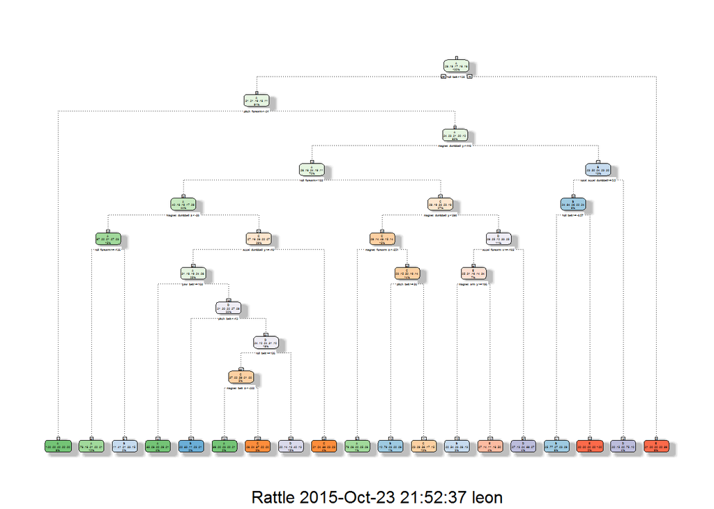

```r
treeModel <- rpart(classe ~ ., data=trainset, method="class")
fancyRpartPlot(treeModel)
```

Preparing the answers

```r
pml_write_files = function(x){
  n = length(x)
  for(i in 1:n){
    filename = paste0("problem_id_",i,".txt")
    write.table(x[i],file=filename,quote=FALSE,row.names=FALSE,col.names=FALSE)
  }
}

pml_write_files(predict_result)
```